```python
import matplotlib.pyplot as plt
import numpy as np
import seaborn as sns
import os

# Crear el directorio 'imgs' si no existe
os.makedirs('imgs', exist_ok=True)

# Configuración estética global: Colores de granos y tostados
coffee_palette = ['#3C2A21', '#543A20', '#B0926A', '#E1C78F', '#603601']
sns.set_theme(style="whitegrid")
```

# **1. Gráfico de Líneas: Curva de Optimización Cognitiva**

Este gráfico ilustra la evolución de los niveles de concentración y productividad de un desarrollador tras la primera taza de la mañana (08:00 AM). Se eligió esta visualización de serie temporal para demostrar el "boost" inmediato de la cafeína y la importancia de la ventana de mantenimiento para evitar el crash de media tarde.

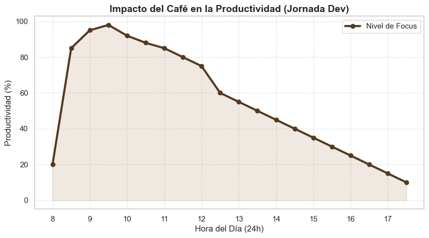

```python
tiempo = np.arange(8, 18, 0.5) # De 8am a 5pm
# Modelo de productividad: sube rápido, se mantiene y baja
productividad = [20, 85, 95, 98, 92, 88, 85, 80, 75, 60, 55, 50, 45, 40, 35, 30, 25, 20, 15, 10]

plt.figure(figsize=(10, 5))
plt.plot(tiempo, productividad, marker='o', color='#543A20', linewidth=3, label='Nivel de Focus')

plt.title('Impacto del Café en la Productividad (Jornada Dev)', fontsize=14, fontweight='bold')
plt.xlabel('Hora del Día (24h)', fontsize=12)
plt.ylabel('Productividad (%)', fontsize=12)
plt.xticks(np.arange(8, 19, 1))
plt.fill_between(tiempo, productividad, color='#B0926A', alpha=0.2)
plt.legend()
plt.grid(True, linestyle='--', alpha=0.5)

plt.savefig('imgs/line_plot.png', dpi=300, bbox_inches='tight')
plt.show()
```

# **2. Gráfico de Barras: Consumo Promedio por Rol en Tech**

Se comparan los hábitos de consumo de café entre diferentes departamentos de una empresa de software. El gráfico de barras es ideal para esta comparación categórica, evidenciando cómo en el área de Ingeniería (Backend/DevOps) el café no es solo una bebida, sino un combustible esencial para la resolución de bugs complejos.

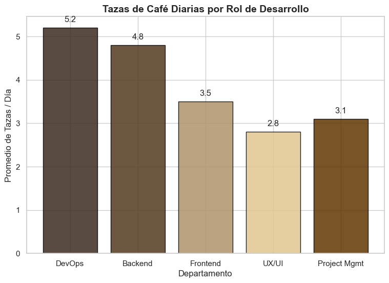

```python
roles = ['DevOps', 'Backend', 'Frontend', 'UX/UI', 'Project Mgmt']
tazas_dia = [5.2, 4.8, 3.5, 2.8, 3.1]

plt.figure(figsize=(9, 6))
bars = plt.bar(roles, tazas_dia, color=coffee_palette, edgecolor='black', alpha=0.85)

plt.title('Tazas de Café Diarias por Rol de Desarrollo', fontsize=14, fontweight='bold')
plt.xlabel('Departamento', fontsize=12)
plt.ylabel('Promedio de Tazas / Día', fontsize=12)

# Añadir etiquetas de valor sobre las barras
for bar in bars:
    yval = bar.get_height()
    plt.text(bar.get_x() + bar.get_width()/2, yval + 0.1, yval, ha='center', va='bottom')

plt.savefig('imgs/bar_chart.png', dpi=300, bbox_inches='tight')
plt.show()
```

# **3. Histograma: Variabilidad de Cafeína en Espresso Shots**

Este gráfico muestra la distribución del contenido de cafeína (mg) en 500 extracciones experimentales de un grano tipo Bourbon. Se seleccionó un histograma para validar la consistencia de la molienda; una distribución estrecha y centrada indica una técnica de barismo profesional y una extracción equilibrada.

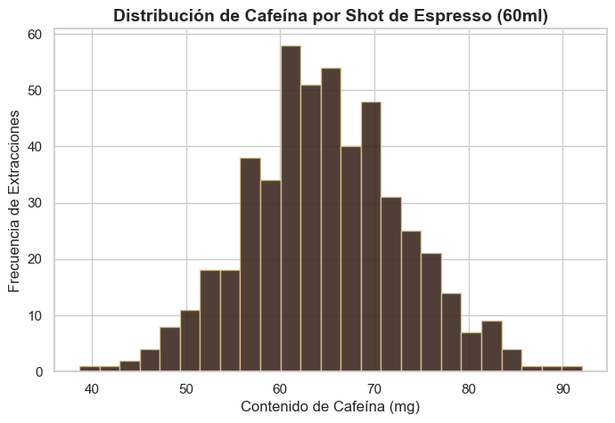

```python
# Simulación de cafeína en mg por shot
cafeina_mg = np.random.normal(65, 8, 500)

plt.figure(figsize=(8, 5))
plt.hist(cafeina_mg, bins=25, color='#3C2A21', edgecolor='#E1C78F', alpha=0.9)

plt.title('Distribución de Cafeína por Shot de Espresso (60ml)', fontsize=14, fontweight='bold')
plt.xlabel('Contenido de Cafeína (mg)', fontsize=12)
plt.ylabel('Frecuencia de Extracciones', fontsize=12)

plt.savefig('imgs/histogram.png', dpi=300, bbox_inches='tight')
plt.show()
```

# **4. Gráfico de Dispersión: Granulometría vs. Calidad de Extracción**

Aquí analizamos la relación entre el tamaño de la molienda (en micras) y el puntaje de sabor (1-100). Elegí el gráfico de dispersión para identificar el "punto dulce" (Sweet Spot); se observa claramente que una molienda ni muy gruesa ni muy fina es la clave para evitar la sub-extracción o el amargor excesivo.

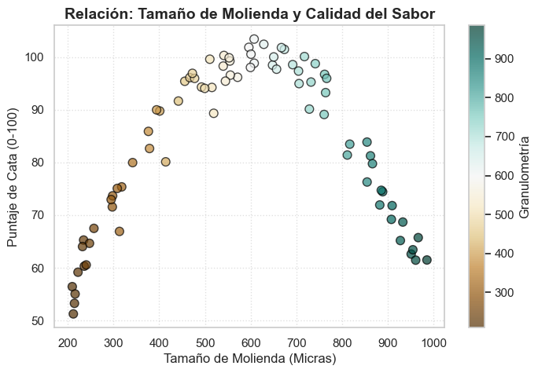

```python
# Datos simulados: molienda (x) vs sabor (y)
molienda_micras = np.random.uniform(200, 1000, 80)
sabor_score = 100 - 0.0003 * (molienda_micras - 600)**2 + np.random.normal(0, 3, 80)

plt.figure(figsize=(8, 5))
plt.scatter(molienda_micras, sabor_score, c=molienda_micras, cmap='BrBG', s=60, edgecolors='black', alpha=0.7)

plt.title('Relación: Tamaño de Molienda y Calidad del Sabor', fontsize=14, fontweight='bold')
plt.xlabel('Tamaño de Molienda (Micras)', fontsize=12)
plt.ylabel('Puntaje de Cata (0-100)', fontsize=12)
plt.colorbar(label='Granulometría')
plt.grid(True, linestyle=':', alpha=0.6)

plt.savefig('imgs/scatter_plot.png', dpi=300, bbox_inches='tight')
plt.show()
```

# **5. Heatmap: Correlación entre Variables de Preparación**

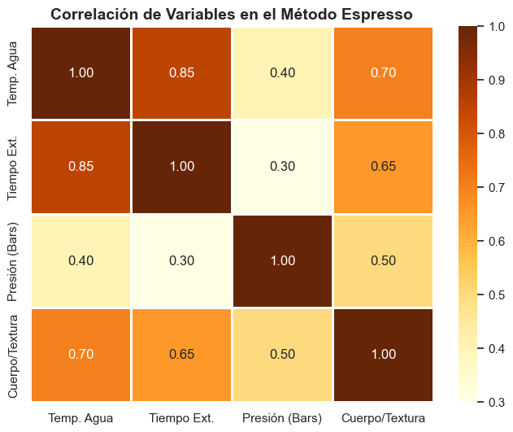

```python
import pandas as pd

# Crear matriz de correlación simulada
data = {
    'Temp. Agua': [1, 0.85, 0.4, 0.7],
    'Tiempo Ext.': [0.85, 1, 0.3, 0.65],
    'Presión (Bars)': [0.4, 0.3, 1, 0.5],
    'Cuerpo/Textura': [0.7, 0.65, 0.5, 1]
}
df_corr = pd.DataFrame(data, index=['Temp. Agua', 'Tiempo Ext.', 'Presión (Bars)', 'Cuerpo/Textura'])

plt.figure(figsize=(8, 6))
sns.heatmap(df_corr, annot=True, cmap='YlOrBr', fmt='.2f', linewidths=1)

plt.title('Correlación de Variables en el Método Espresso', fontsize=14, fontweight='bold')
plt.savefig('imgs/custom_plot.png', dpi=300, bbox_inches='tight')
plt.show()
```